# Assessment_2_dylan_rohan

### Assessment 2 - Project

Dylan Rohan - a1844790

## An analysis of a citizen science program involving Frog Sightings in Port Phillip and Westernport regions of Victoria, Australia

### Introduction

This dataset is compiled from a long running citizen science program, but also has data added from the Victorian Biodiversity Atlas and Melbourne water surveys. The area is mostly contained to the Port Phillip and Westernport Regions of Victoria. It is far from perfect as I've found through this assignment but it has allowed me to demonstrate my ability and attempt things beyond the scope of this unit. Throughout this assignment I have incorporated other data, notably using the geopy library to find location names from latitude and longitude coordinates (just so I could see clearly where the data came from through the analysis) and an attempt at adding weather data (*see Extension*).

Below I read in the data to a pandas Data Frame and look at the data in more detail. For each chart I will describe its purpose, a run down on how it was made, what information can be taken from it, and what information cannot be taken from it.

```python
# Importing modules
import datetime                                         # For timestamped data
import pandas as pd                                     # To create and manipulate pandas Dataframes
import numpy as np                                      # To use arrays and benefit from vectorizarion
import matplotlib.pyplot as plt                         # To use generate embedded plots
from matplotlib.lines import Line2D                     # To create legend handles
from calendar import day_name                           # to create day names from datetime data
from mpl_toolkits.basemap import Basemap                # To create a map to plot on
# Had to install pip to get the geopy package
# from geopy.geocoders import Nominatim                 # To turn coordinates into suburb names for quick viewing
```

```python
# Importing and compiling files
frog_data = pd.read_csv("Frog_census_Records.csv")
```

```python
# Making data frame and checking it's shape
frog_df = pd.DataFrame(frog_data)
print("The shape of the data frame is: ", frog_df.shape)

# Ensuring that each common name matches a unique Scientific name
sci_com_name = frog_df.groupby(['Scientific_name','Common_name']).size().reset_index().rename(columns={0:'count'})

# Fixing duality of answers between scientific name and multiple common names:
litoria_peronii = ["Peron's Tree Frog","Peronâ€™s Tree Frog"]
for name in litoria_peronii:
    frog_df.loc[(frog_df.Common_name == name,'Common_name')]="Peron's Tree Frog"

# Fixing column data types:
frog_df['Date']= pd.to_datetime(frog_df['Date'])
frog_df['Time_Start']= pd.to_datetime(frog_df['Time_Start'])

print("\nHere is a list of data types for each column, keeping in mind that numpy stores strings as objects\n",
      frog_df.dtypes)
print("\nThe common name of a frog can apply to several species of frog as you can see in the dataframe below:")
sci_com_name
```

```
The shape of the data frame is:  (31666, 12)

Here is a list of data types for each column, keeping in mind that numpy stores strings as objects
 X                             float64
Y                             float64
FID                             int64
Unique_ID                       int64
Date                   datetime64[ns]
Time_Start             datetime64[ns]
Latitude                      float64
Longitude                     float64
Type_of_observation            object
Scientific_name                object
Common_name                    object
Number                         object
dtype: object

The common name of a frog can apply to several species of frog as you can see in the dataframe below:
```

|  | Scientific_name | Common_name | count |
| --- | --- | --- | --- |
| 0 | Crinia parinsignifera | Eastern Sign-bearing Froglet | 184 |
| 1 | Crinia signifera | Eastern Common Froglet | 9203 |
| 2 | Geocrinia laevis | Tasmanian Smooth Froglet | 2 |
| 3 | Geocrinia victoriana | Victorian Smooth Froglet | 970 |
| 4 | Limnodynastes dumerilii | Eastern Banjo Frog | 3174 |
| 5 | Limnodynastes dumerilii dumerilii | Eastern Banjo Frog | 50 |
| 6 | Limnodynastes dumerilii insularis | Eastern Banjo Frog | 101 |
| 7 | Limnodynastes dumerilii variegatus | Eastern Banjo Frog | 24 |
| 8 | Limnodynastes peronii | Striped Marsh Frog | 1690 |
| 9 | Limnodynastes tasmaniensis | Spotted Marsh Frog | 3138 |
| 10 | Limnodynastes tasmaniensis NCR | Spotted Marsh Frog | 6 |
| 11 | Limnodynastes tasmaniensis SCR | Spotted Marsh Frog | 952 |
| 12 | Litoria ewingii | Southern Brown Tree Frog | 5069 |
| 13 | Litoria ewingii GROUP | Southern Brown Tree Frog | 3 |
| 14 | Litoria ewingii SOUTHERN | Southern Brown Tree Frog | 507 |
| 15 | Litoria fallax | Eastern Dwarf Tree Frog | 73 |
| 16 | Litoria lesueuri | Rocky River (Lesueur's) Frog | 91 |
| 17 | Litoria nudidigitus | Southern Leaf Green Tree Frog | 1 |
| 18 | Litoria paraewingi | Plains Brown Tree Frog | 11 |
| 19 | Litoria peronii | Peron's Tree Frog | 326 |
| 20 | Litoria peronii | Peronâ€™s Tree Frog | 55 |
| 21 | Litoria raniformis | Growling Grass Frog | 2480 |
| 22 | Litoria raniformis | Growling grass frog | 1 |
| 23 | Litoria verreauxii | Whistling Tree Frog | 36 |
| 24 | Litoria verreauxii (ssp. unknown) | Whistling Tree Frog | 427 |
| 25 | Litoria verreauxii alpina | Alpine Whistling Tree Frog | 1 |
| 26 | Litoria verreauxii verreauxii | Whistling Tree Frog | 1761 |
| 27 | Neobatrachus sudellae | Common Spadefoot Toad | 218 |
| 28 | Paracrinia haswelli | Red-groined Froglet | 52 |
| 29 | Pseudophryne bibronii | Brown Toadlet | 319 |
| 30 | Pseudophryne dendyi | Dendy's Toadlet | 36 |
| 31 | Pseudophryne semimarmorata | Southern Toadlet | 705 |

```python
# Preparing an anonymous function that will use longitude and latitudes to give a suburb name:

#### THIS WAS LEFT TO COMPLETE OVERNIGHT SO I SAVED IT AS A CSV AND WON"T BE DOING IT AGAIN!!!! ####

# geolocator = Nominatim(user_agent="getlocation")
# frog_df["Suburb"] = frog_df.apply(lambda x:geolocator.reverse(str(x["Latitude"])+",
# "+str(x["Longitude"])).address.split(",")[1], axis=1)
```

```python
#frog_df.to_csv("frog_data.csv")


#################################################
#Loading in the new file with A suburb column
frog_df = pd.read_csv("frog_data.csv")

# reapplying the formatting from above:
litoria_peronii = ["Peron's Tree Frog","Peronâ€™s Tree Frog"]
for name in litoria_peronii:
    frog_df.loc[(frog_df.Common_name == name,'Common_name')]="Peron's Tree Frog"

# Fixing column data types:
frog_df['Date']= pd.to_datetime(frog_df['Date'])
frog_df['Time_Start']= pd.to_datetime(frog_df['Time_Start'])

print("\nRechecking data types\n",frog_df.dtypes)
```

```
Rechecking data types
 Unnamed: 0                      int64
Unnamed: 0.1                    int64
Unnamed: 0.1.1                  int64
X                             float64
Y                             float64
FID                             int64
Unique_ID                       int64
Date                   datetime64[ns]
Time_Start             datetime64[ns]
Latitude                      float64
Longitude                     float64
Type_of_observation            object
Scientific_name                object
Common_name                    object
Number                         object
Suburb                         object
dtype: object
```

```python
print("Notice we now have a 'Suburb' column")
frog_df.head(5)
```

```
Notice we now have a 'Suburb' column
```

|  | Unnamed: 0 | Unnamed: 0.1 | Unnamed: 0.1.1 | X | Y | FID | Unique_ID | Date | Time_Start | Latitude | Longitude | Type_of_observation | Scientific_name | Common_name | Number | Suburb |
| --- | --- | --- | --- | --- | --- | --- | --- | --- | --- | --- | --- | --- | --- | --- | --- | --- |
| 0 | 0 | 0 | 0 | 336582.9095 | 5.848231e+06 | 1 | 1 | 1960-01-15 | NaT | -37.498402 | 145.151306 | Incidental | Limnodynastes dumerilii | Eastern Banjo Frog | unknown | Whittlesea |
| 1 | 1 | 1 | 1 | 336582.9095 | 5.848231e+06 | 2 | 2 | 1960-01-15 | NaT | -37.498402 | 145.151306 | Incidental | Limnodynastes dumerilii | Eastern Banjo Frog | unknown | Whittlesea |
| 2 | 2 | 2 | 2 | 336582.9095 | 5.848231e+06 | 3 | 3 | 1960-01-15 | NaT | -37.498402 | 145.151306 | Incidental | Limnodynastes dumerilii | Eastern Banjo Frog | unknown | Whittlesea |
| 3 | 3 | 3 | 3 | 336582.9095 | 5.848231e+06 | 4 | 4 | 1960-01-15 | NaT | -37.498402 | 145.151306 | Incidental | Limnodynastes dumerilii | Eastern Banjo Frog | unknown | Whittlesea |
| 4 | 4 | 4 | 4 | 336582.9095 | 5.848231e+06 | 5 | 5 | 1960-01-15 | NaT | -37.498402 | 145.151306 | Incidental | Limnodynastes dumerilii | Eastern Banjo Frog | unknown | Whittlesea |

Note: We will only consider common names as the scientific name is likley incorrect in a few instances (considering the data is from the general public and not herpatologists) but a common name can apply to a group of species of similar phenotypes and is far more likely to be correct.

### Plot 1 - Pie chart - What proportion of frogs did they find?

(Categorical data comparison)

Below I have styled a pie chart that shows the proportion of times that at least one frog of a particular species was reported.

**How it was done**: I used the value_counts() function from the pandas library to create a frequency series. Upon viewing I thought it necessary to compile a few of the less common frog species into an 'Other' category. I created a list of these species, copied the frog_df dataframe and altered the Common_name attribute value to 'Other' for the frogs in question. I created a new frequency series as above and created two ordered lists (with the to_list() function from the pandas library); one for the index (Common names) and one with the corresponding values. These lists were used for labelling. The frequency series was called on by the plot() function in the matplotlib library to create the pie chart.

**Further commentary**: It does not show the count of frogs observed, that we will see later. This simply shows you the frequency that at least one frog of a given species was reported. Each row of the dataframe represents a report. There were more than a few frogs that were not reported all that much, so I grouped them into an 'Other' Category that is broken down in *figure 2* (You'll notice I colour coded the wedge and bar chart so there is no confusion about what is being shown). I could have simply used a legend and been done with this figure, but I decided to demonstrate annotation with arrows.

What this Figure shows:

- The proportion of reported sightings of at least one frog in a species
- Two speices alone make up just under half of all reported sightings
- More than half of the species reported take up less than 5% of reports

What this chart does not show:

- The proportion of species in the frog population. These are sightings, it makes no commentary on the number sighted.

```
Eastern Common Froglet      9203
Southern Brown Tree Frog    5579
Spotted Marsh Frog          4096
Eastern Banjo Frog          3349
Growling Grass Frog         2480
Whistling Tree Frog         2224
Striped Marsh Frog          1690
Other                       1370
Victorian Smooth Froglet     970
Southern Toadlet             705
Name: Common_name, dtype: int64
```

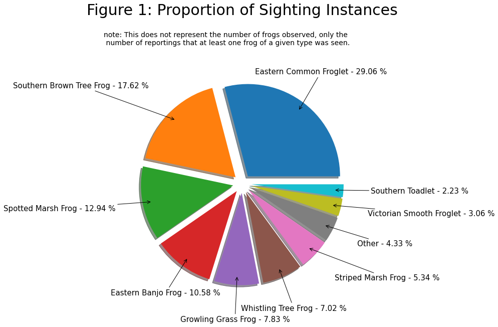

```python
# Creating a series of frequencies indexed to the common name then creating arrays to tie together in a Pie chart:
freq_all = frog_df.Common_name.value_counts()
common_names_all = np.char.array(freq_all.index.to_list())
count_all = np.array(freq_all.to_list())

# Too infrequent to have their own wedge each, created a new dataframe with the 'other' category:
frog_df_pie = frog_df.copy()
other = ["Peron's Tree Frog","Brown Toadlet",'Common Spadefoot Toad', 'Eastern Sign-bearing Froglet',
           "Rocky River (Lesueur's) Frog", 'Eastern Dwarf Tree Frog',
           'Red-groined Froglet', "Dendy's Toadlet",
           'Plains Brown Tree Frog', 'Tasmanian Smooth Froglet',
           'Alpine Whistling Tree Frog', 'Growling grass frog',
           'Southern Leaf Green Tree Frog']
for name in other:
    frog_df_pie.loc[(frog_df_pie.Common_name == name,'Common_name')]="Other"

# Remaking frequency series to check:
freq = frog_df_pie.Common_name.value_counts()
common_names = np.char.array(freq.index.to_list())
print(freq)

# Assigning figure properties:
fig, ax = plt.subplots(figsize=(8, 8), subplot_kw=dict(aspect="equal"))

# Setting percentage
percentage = 100*(freq/count_all.sum())

# Creating labels
labels = ['{0} - {1:1.2f} %'.format(i,j) for i,j in zip(common_names, percentage)]

# Creating the pie chart
wedges, texts = plt.pie(freq,
                         startangle = 0,
                        explode = [.1,.1,.1,.1,.1,.1,.1,.1,.1,.1,],
                       shadow = True)

# Creating the arrow styling
arrow_kw = dict(arrowprops=dict(arrowstyle="->"), va="baseline")

# Assigning the label and arrow to positions
for p, label in zip(wedges, labels):
    ang = np.deg2rad((p.theta1 + p.theta2)/2)
    y = np.sin(ang)
    x = np.cos(ang)
    horizontalalignment = "center" if abs(x) < abs(y) else "right" if x < 0 else "left"
    ax.annotate(label, xy=(1*x, 1*y), xytext=(1.4*x, 1.5*y),
                horizontalalignment=horizontalalignment, **arrow_kw, fontsize =15)

# Chart features
plt.title("Figure 1: Proportion of Sighting Instances",fontsize = 30, pad = 120)
plt.text(-1.5,1.5,'note: This does not represent the number of frogs observed, only the\n number of reportings that at least one frog of a given type was seen.', fontsize = 14)
plt.axis("equal")
plt.show()
```

### Plot 2 - Bar chart - What does the data say about those in the 'Other' category?

(Categorical data comparison)

Below I have styled a bar chart that takes the group of frogs in the 'Other' category that you will recall from *figure 1* and shows the count of reported sightings of at least one frog.

**How it was done**: I took the frequency series created above and converted it into a pandas dataframe in order to view all common_names and counts. I then created seperate ordered lists of Common names and the corresponding count values to filter for frogs in the 'Other' category. I call on these lists using the plot() function from the matplotlib library to create a bar chart.

**Further commentary**: Notice we are no longer measuring proportions, but count numbers over the course of this very long citizen science program (1960-2019). I have titled and subtitled it in a way that leaves no room for confusion, and colour coded it to match the wedge from above in *figure 1* to further remove confusion. I've also placed the count totals on the peak of each bar to give some exactness to its interpretation.

What this figure shows:

- Of more than 30,000 reports, there were less than 400 reports for each of these species. In some cases, only 1.
- This could mean two things:
  - Perhaps the lack of sightings could be taken as an indication of camouflage and survival fitness (more research required)
  - The species population is low and therefore sighting is infrequent

What this figure does not show:

- The proportion of individual frogs
- The most common frogs in the whole study

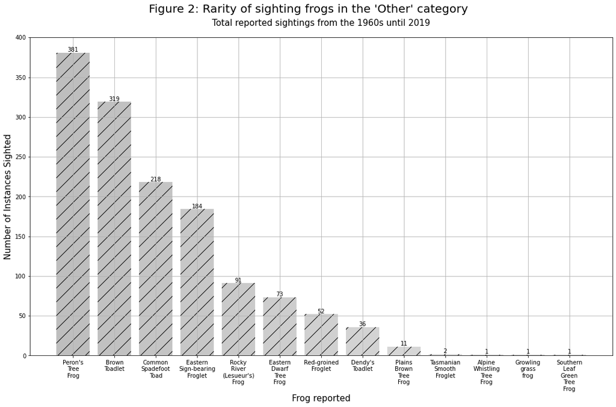

```python
# Bar chart to represent the count for those in the 'other' list:
frequency_for_all = pd.DataFrame(freq_all)
frequency_for_all.columns = ["count"]

# Creating lists to map onto the chart
index = ["Peron's\nTree\nFrog","Brown\nToadlet",'Common\nSpadefoot\nToad',
         'Eastern\nSign-bearing\nFroglet',"Rocky\nRiver\n(Lesueur's)\nFrog",
         'Eastern\nDwarf\nTree\nFrog', 'Red-groined\nFroglet', "Dendy's\nToadlet",
         'Plains\nBrown\nTree\nFrog', 'Tasmanian\nSmooth\nFroglet',
         'Alpine\nWhistling\nTree\nFrog', 'Growling\ngrass\nfrog',
         'Southern\nLeaf\nGreen\nTree\nFrog']

frequency = [381,  319, 218,  184,   91,   73,   52,   36,   11,    2,    1,    1,    1] # simplest way to place annotated totals
colors = [40, 50, 60, 70, 80, 90, 100, 110, 120, 130] #grey to match the colour of it's wedge in the pie chart

# Creating the figure
fig2 = plt.figure(figsize=(15,10))
plt.grid(True)
plt.bar(x = index, height = frequency, color = [str(x/255) for x in colors], alpha  = 0.3, hatch = '/')

#Chart features
plt.title("Total reported sightings from the 1960s until 2019", fontsize =15, pad = 20)
plt.ylabel("Number of Instances Sighted", fontsize= 15)
plt.xlabel("Frog reported", fontsize= 15)
plt.suptitle("Figure 2: Rarity of sighting frogs in the 'Other' category", fontsize =20)

# Labelling totals on the peak of each bar
for number in range(len(frequency)):
    plt.annotate(str(frequency[number]), xy=(index[number],frequency[number]), ha='center', va='bottom', fontsize = 10)
plt.tight_layout()
plt.show()
```

```python
# Tabular view:
frequency_for_all['Proportion_(%)'] = 100*(frequency_for_all["count"] / frequency_for_all["count"].sum())
print("See the tabular view of the above data below:")
frequency_for_all
```

```
See the tabular view of the above data below:
```

|  | count | Proportion_(%) |
| --- | --- | --- |
| Eastern Common Froglet | 9203 | 29.062717 |
| Southern Brown Tree Frog | 5579 | 17.618266 |
| Spotted Marsh Frog | 4096 | 12.935009 |
| Eastern Banjo Frog | 3349 | 10.576012 |
| Growling Grass Frog | 2480 | 7.831744 |
| Whistling Tree Frog | 2224 | 7.023306 |
| Striped Marsh Frog | 1690 | 5.336954 |
| Victorian Smooth Froglet | 970 | 3.063222 |
| Southern Toadlet | 705 | 2.226363 |
| Peron's Tree Frog | 381 | 1.203183 |
| Brown Toadlet | 319 | 1.007390 |
| Common Spadefoot Toad | 218 | 0.688436 |
| Eastern Sign-bearing Froglet | 184 | 0.581065 |
| Rocky River (Lesueur's) Frog | 91 | 0.287374 |
| Eastern Dwarf Tree Frog | 73 | 0.230531 |
| Red-groined Froglet | 52 | 0.164214 |
| Dendy's Toadlet | 36 | 0.113687 |
| Plains Brown Tree Frog | 11 | 0.034738 |
| Tasmanian Smooth Froglet | 2 | 0.006316 |
| Alpine Whistling Tree Frog | 1 | 0.003158 |
| Growling grass frog | 1 | 0.003158 |
| Southern Leaf Green Tree Frog | 1 | 0.003158 |

### Plot 3 - Line chart

Below i create a line chart. It can be used to answer mutliple questions, here are just three:

1. What time of year were majority of frogs observed?
2. When does the program have the most activity?
3. When in the programs life time did most of the data come along?

(Quantitative to Quantitative data relationship)

**How it was done**: First I used the count_values() function from the pandas library to create a frequency Series indicating the amount of reports recieved on each day. I then converted this to a dataframe and created a time range Series from the min() and max() datetime values of the 'Date' column using the corresponding datetime function from the datetime library. I then bound these together so that any dates not present could be given a count value of zero. I then seperated the data by decade and assigned a key to each decade in a dictionary so that I could easily call on them when I created subplots using the subplot() function from the matplotlib library.

**Further commentary**: Line charts are excellent for showing a time series. To see participation over the course of the program, I have created a line chart for each decade. Keep in mind this includes voluntary and circumstancial participation as the dataset has compiled data from surveys of different areas over the years. In any case, it show there was interest in frogs over time and how that interest tracked over the course of the program.

What this figure shows:

- The first few decades don't show any clear trends year to year, but there does appear to be a lull in participation over the colder months. This could be due to human behaviour when it comes to the colder climate, or survival stratergies of frogs as well as their popualtion counts.
- In the first few decades participation was low but there does appear to be lots of activity since the 1990s. I suspect this is when schools started to teach more about biodiversity and participation online began to develop.
- At a glance it isn't clear if frogs were sighted more regularly at any particular time of year.

What this figure does not show:

- That the 2000s had low activity (be mindful of the y-axis magnitudes)
- The number of frogs sighted over time, again it is only showing report counts over time

```python
# creating a dataframe of Dates and how many reports were submitted on that date.
instances_by_date = pd.DataFrame(frog_df.Date.value_counts())

# Just neatening the data for analysis purposes
instances_by_date["date"]=instances_by_date.index
instances_by_date["Instances"]=instances_by_date["Date"]
instances_by_date.drop(['Date'], axis=1, inplace=True)
instances_by_date.sort_index(inplace=True)
instances_by_date.index = pd.to_datetime(instances_by_date.index)

print("The most recent date was", instances_by_date.date.max(), "and the earliest date was", instances_by_date.date.min())
```

```
The most recent date was 2018-12-20 00:00:00 and the earliest date was 1960-01-15 00:00:00
```

```python
# Filling missing enteries and giving them values of zero
datetimerange =pd.date_range('01.01.1960', '31.12.2020', freq='D')
s = pd.Series(index=datetimerange)
instances_by_date = pd.concat([instances_by_date,s[~s.index.isin(instances_by_date.index)]]).sort_index()
instances_by_date = instances_by_date.drop([0],axis=1).fillna(0)
```

```python
# Slice it into the 6 different decades:
Decade1 = instances_by_date["1960-01-01":"1969-12-31"]
Decade2 = instances_by_date["1970-01-01":"1979-12-31"]
Decade3 = instances_by_date["1980-01-01":"1989-12-31"]
Decade4 = instances_by_date["1990-01-01":"1999-12-31"]
Decade5 = instances_by_date["2000-01-01":"2009-12-31"]
Decade6 = instances_by_date["2010-01-01":"2019-12-31"]
decades = {1:Decade1, 2:Decade2, 3:Decade3, 4:Decade4, 5:Decade5, 6:Decade6}
```

```
Occassionally the text moves despite me not altering the code in any way. Unsure how to fix, hopefully its just my computer
```

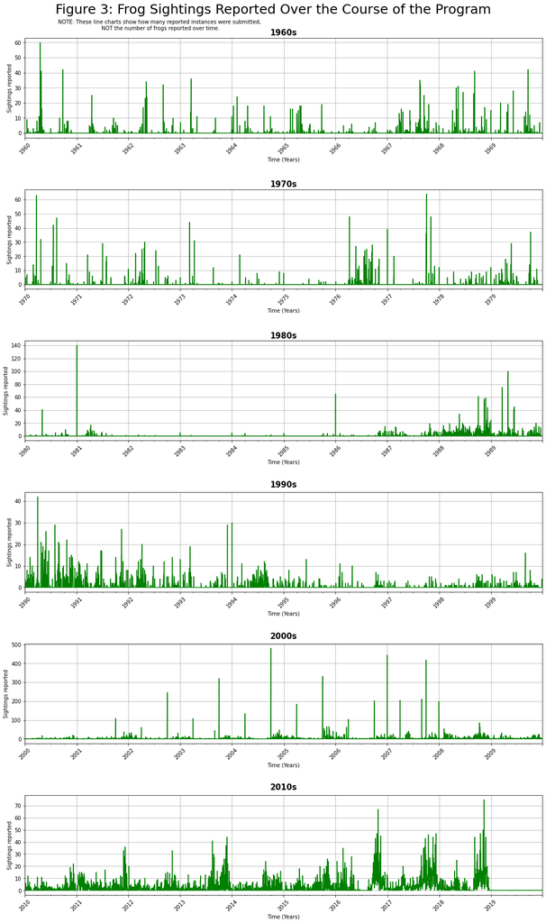

```python
# Creating Line subplots
fig3, axes = plt.subplots(nrows = 6, ncols = 1)
for i, value in enumerate(decades):
    decades[value].plot(ax=axes[i],
                      fontsize =10,
                      figsize = (15,25),
                      style = "g",
                      xlabel= "Time (Years)",
                      ylabel= "Sightings reported",
                      grid =True,
                      legend = False)

# Styling individual subplots, couldn't figure out how to loop through
plt.subplot(6, 1, 1)
plt.xticks(rotation=45)
plt.title("1960s", pad =5, fontsize=15, fontweight="bold")

plt.subplot(6, 1, 2)
plt.xticks(rotation=45)
plt.title("1970s", pad =5, fontsize=15,fontweight="bold")

plt.subplot(6, 1, 3)
plt.xticks(rotation=45)
plt.title("1980s", pad =5, fontsize=15,fontweight="bold")

plt.subplot(6, 1, 4)
plt.xticks(rotation=45)
plt.title("1990s", pad =10, fontsize=15, fontweight="bold")

plt.subplot(6, 1, 5)
plt.xticks(rotation=45)
plt.title("2000s", pad =10, fontsize=15, fontweight="bold")

plt.subplot(6, 1, 6)
plt.xticks(rotation=45)
plt.title("2010s", pad =10, fontsize=15, fontweight="bold")

# Final styling touches
plt.suptitle("Figure 3: Frog Sightings Reported Over the Course of the Program", fontsize =25)
fig3.tight_layout(pad=3.0)
plt.text(0.2,1.92, "NOTE: These line charts show how many reported instances were submitted,\n NOT the number of frogs reported over time.",
        horizontalalignment='center',
        verticalalignment='center',
        transform = ax.transAxes)
print("\nOccassionally the text moves despite me not altering the code in any way. Unsure how to fix, hopefully its just my computer ")
plt.show()
```

### Plot 4 - What Daily characteristics did the participation data have for each decade?

(Analysis of Quantitative data)

Below I have styled histogram subplots for each decade in order to assess participation

**Further comentary**: Histograms are an excellent way to asses the spread and shape of data.

What this Figure shows:

- It was uncommon to get more than 10 reports per day
- Confirms participation increased from the 1990s (y-axis magnitudes change)
- In all decades the median was lower than the mean indicating there are several days without reports present
- the histograms have a right skew,

What this figure does not show you:

- This chart is fairly clear

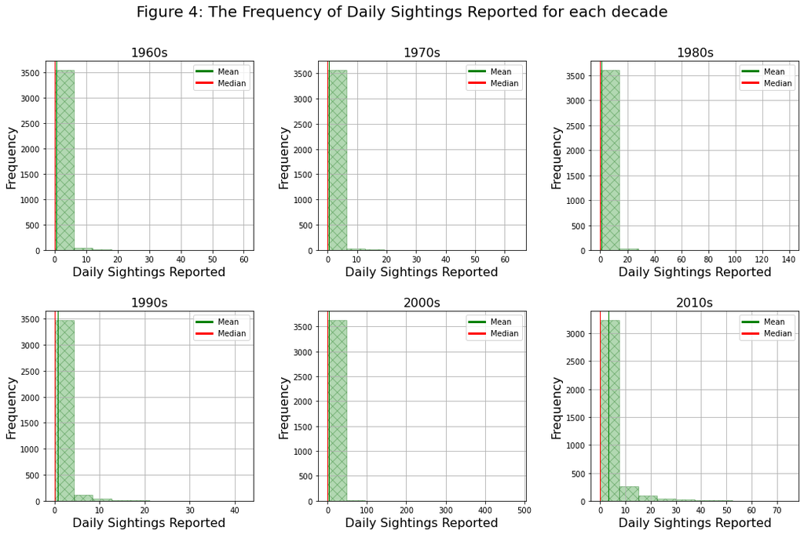

```python
# Creating legend
legend_elements = [Line2D([0], [0], color='g', lw=3, label='Mean'),
                   Line2D([0], [0], color='r', lw=3, label='Median')]

# Creating figure
fig4, plots = plt.subplots(3,2, figsize=(15,10))

# Creating subplots, couldn't find a way to loop and alter the labels at the same time
plt.subplot(2, 3, 1)
plt.hist(Decade1["Instances"],color = "g", ec ='darkgreen', hatch ="xx", alpha = 0.3)
plt.title("1960s", fontsize = 16)
plt.ylabel("Frequency", fontsize = 16)
plt.xlabel("Daily Sightings Reported", fontsize = 16)
plt.axvline(Decade1.Instances.mean(), color='g', linestyle='solid', linewidth=1)
plt.axvline(Decade1.Instances.median(), color='r', linestyle='solid', linewidth=1)
plt.legend(handles=legend_elements, loc='upper right')
plt.grid(True)

plt.subplot(2, 3, 2)
plt.hist(Decade2["Instances"],color = "g", ec ='darkgreen', hatch ="xx", alpha = 0.3)
plt.title("1970s", fontsize = 16)
plt.ylabel("Frequency", fontsize = 16)
plt.xlabel("Daily Sightings Reported", fontsize = 16)
plt.axvline(Decade2.Instances.mean(), color='g', linestyle='solid', linewidth=1)
plt.axvline(Decade2.Instances.median(), color='r', linestyle='solid', linewidth=1)
plt.legend(handles=legend_elements, loc='upper right')
plt.grid(True)

plt.subplot(2, 3, 3)
plt.hist(Decade3["Instances"],color = "g", ec ='darkgreen', hatch ="xx", alpha = 0.3)
plt.title("1980s", fontsize = 16)
plt.ylabel("Frequency", fontsize = 16)
plt.xlabel("Daily Sightings Reported", fontsize = 16)
plt.axvline(Decade3.Instances.mean(), color='g', linestyle='solid', linewidth=1)
plt.axvline(Decade3.Instances.median(), color='r', linestyle='solid', linewidth=1)
plt.legend(handles=legend_elements, loc='upper right')
plt.grid(True)

plt.subplot(2, 3, 4)
plt.hist(Decade4["Instances"],color = "g", ec ='darkgreen', hatch ="xx", alpha = 0.3)
plt.title("1990s", fontsize = 16)
plt.ylabel("Frequency", fontsize = 16)
plt.xlabel("Daily Sightings Reported", fontsize = 16)
plt.axvline(Decade4.Instances.mean(), color='g', linestyle='solid', linewidth=1)
plt.axvline(Decade4.Instances.median(), color='r', linestyle='solid', linewidth=1)
plt.legend(handles=legend_elements, loc='upper right')
plt.grid(True)

plt.subplot(2, 3, 5)
plt.hist(Decade5["Instances"],color = "g", ec ='darkgreen', hatch ="xx", alpha = 0.3)
plt.title("2000s", fontsize = 16)
plt.ylabel("Frequency", fontsize = 16)
plt.xlabel("Daily Sightings Reported", fontsize = 16)
plt.axvline(Decade5.Instances.mean(), color='g', linestyle='solid', linewidth=1)
plt.axvline(Decade5.Instances.median(), color='r', linestyle='solid', linewidth=1)
plt.legend(handles=legend_elements, loc='upper right')
plt.grid(True)

plt.subplot(2, 3, 6)
plt.hist(Decade6["Instances"],color = "g", ec ='darkgreen', hatch ="xx", alpha = 0.3)
plt.title("2010s", fontsize = 16)
plt.ylabel("Frequency", fontsize = 16)
plt.xlabel("Daily Sightings Reported", fontsize = 16)
plt.axvline(Decade5.Instances.mean(), color='g', linestyle='solid', linewidth=1)
plt.axvline(Decade5.Instances.median(), color='r', linestyle='solid', linewidth=1)
plt.legend(handles=legend_elements, loc='upper right')
plt.grid(True)

plt.suptitle("Figure 4: The Frequency of Daily Sightings Reported for each decade", fontsize=20)
plt.tight_layout(pad=2.5)
plt.show()
```

### Plot 5 - Polar chart - What 'type of observation' was most common? Where did the data come from?

(Analysis of Qualitative data)

Below I have used a polar chart to identify the proportion of observation types.

**How it was done**: First I found all unique values for the type of observation by using the unique() function on the Type_of_observation series taken from the pandas data frame. I then create seven different group lists and place each unique value into one of the seven categories. I then copy the frog_df dataframe so that I can assign the new values to the Type of Observation column without altering the original. Finally I introduce a figure object to populate with the data (using the subplot() function from the matplotlib library), and then I introduce the variables needed to create a polar chart using the bar() function from the matplotlib library.

**Further commentary**: I've elected to use a polar chart instead of a bar chart just to demonstarte that I know how to do it. I've taken the values in the Type_of_observation and categoriesed it into seven generalised categories. This way we can get a general idea of how the data was collected. Notice I ordered them from highest value to lowest value.

What the figure shows:

- Over 4,000 reports were unspecified, thats over 10% of the data
- The amount of frog specific survey reportings was of the same magnitude as the incidental reportings
- More than half of the data comes from frog surveys and incidental sighting reports
- Traps do not appear to be an excellent way to collect frog data

What the figure does not show:

- The specific context of each individual sighting (I have created generalised categories)

```python
# Finding unique values for Type_of_observation
frog_df.Type_of_observation.unique()

# Categorising the Type_of_observation attribute
Incidental = ['Incidental', 'General observations', 'Incidental',
              'General observations','Listening', 'General observation (',
              'Incidental record', 'Under Paver (concrete',]

frog_specific_survey = ['Herp census - active','Pitfall', 'Pitfall with drift fe', 'Frog census',
                        'Frog census (AVW code', 'Pitfall + drift fence', 'Tadpole Trapping', 'Frog survey',
                        'Targeted search', 'Frog Triangulation', 'Dip Net','Frog Census', 'Active search',
                        'Frog Census - sound r', 'Frog transect']

other_context = ['Dusk watch', 'Tile (roof) census',  'Electrofishing (backp', 'Hamer code 9132', 'Hamer code 9129',
         'Hamer code 9128', 'Artificial Substrate', 'Electro-fishing (Bank']


bird_related_survey = ['Owl census','Timed bird census', 'Bird count', 'Birds Australia 500m',
                       'Birds Australia incid','Birds Australia 5km a', 'Bird transect', 'Heard during bird sur',]

any_trap = ['Cage trap','Bat trap', 'Elliott trap', 'Trap (unspecified)','Bait Trap (general)', 'Bait Trap (+light sti',
            'Funnel Trap Drift Fen', 'Fyke Net (fine mesh)', 'Mist net','Fyke Net (fine mesh)', 'Fyke Net (general)',
            'Fyke Net (double wing','Camera - Thermal imag',]

non_specific_animal_survey = ['Fish Survey', 'Golden Sun Moth Adult','Spotlighting','Point spot count',
                              'Spotlighting by area','Spotlighting on foot','Invertebrate Search -','Fixed Point Count',
                              'Opportunistic recordi', 'Opportunistic Recordi']

obs_type = frog_df.copy()

for value in Incidental:
     obs_type.loc[(obs_type.Type_of_observation == value,'Type_of_observation')]= "Incidental"
for value in frog_specific_survey:
     obs_type.loc[(obs_type.Type_of_observation == value,'Type_of_observation')]= "Frog_Specific_Survey"
for value in other_context:
     obs_type.loc[(obs_type.Type_of_observation == value,'Type_of_observation')]= "Other"
for value in bird_related_survey:
     obs_type.loc[(obs_type.Type_of_observation == value,'Type_of_observation')]= "Bird_related_survey"
for value in any_trap:
     obs_type.loc[(obs_type.Type_of_observation == value,'Type_of_observation')]= "Trap"
for value in non_specific_animal_survey:
     obs_type.loc[(obs_type.Type_of_observation == value,'Type_of_observation')]= "Non_specific_animal_survey"

obs_type.loc[(obs_type.Type_of_observation.isnull())]= "Unspecified"

print("Confirming all the data has been categorised into 7 categories: \n",obs_type.Type_of_observation.unique())
```

```
Confirming all the data has been categorised into 7 categories:
 ['Incidental' 'Trap' 'Non_specific_animal_survey' 'Frog_Specific_Survey'
 'Bird_related_survey' 'Other' 'Unspecified']
```

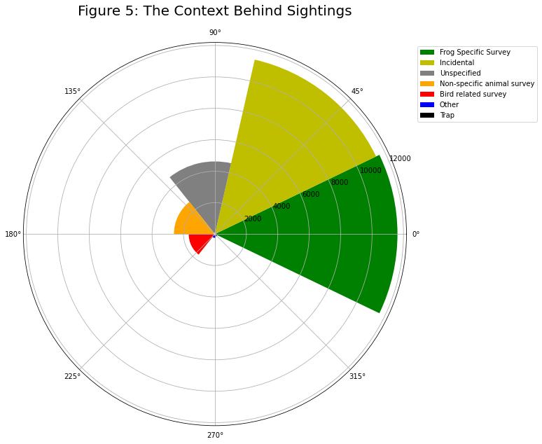

```python
# Creating variables to feed into the polar chart
N = 7
theta = np.arange(0., 2*np.pi, 2*np.pi/N)
colors = np.array(['g', 'y', 'grey', 'orange','r','blue', "black"])
radii = np.array([obs_type.Type_of_observation.value_counts().Frog_Specific_Survey,
                  obs_type.Type_of_observation.value_counts().Incidental,
                  obs_type.Type_of_observation.value_counts().Unspecified,
                  obs_type.Type_of_observation.value_counts().Non_specific_animal_survey,
                  obs_type.Type_of_observation.value_counts().Bird_related_survey,
                  obs_type.Type_of_observation.value_counts().Other,
                  obs_type.Type_of_observation.value_counts().Trap,])

# Creatig and styling the polar chart
fig5, ax = plt.subplots(figsize=(8, 8), subplot_kw=dict(polar=True))
plt.axes([0.025, 0.025, 0.95, 0.95], polar = True)
bars = plt.bar(theta, radii, width = (2*np.pi/N), bottom = 90, color = colors)
plt.title("Figure 5: The Context Behind Sightings", fontsize = 20, pad = 20)
plt.legend(bars, ["Frog Specific Survey","Incidental", "Unspecified",
                  "Non-specific animal survey", "Bird related survey",
                  "Other", "Trap"], bbox_to_anchor=(1.35, 1) )
plt.show()
```

### Plot 6 - Horizontal Bar chart - What time periods had the most participation?

(Analysis of Qualitative data - because we're looking at time intervals and not values)

Below I have created Horizontal bar charts that give the total amount of participation that occurred on a given day month or year.

**How it was done**: First I created columns in the pandas data frame that represented the year, day and month from the 'date' column using the datetime library's dt.year(), dt.month(), and dt.day() functions. When it comes to the new 'weekday' column, I also asked that the name of that day be seen instead using the day_name() function from the calendar library. I categorise the weekdays by first setting the data type to be 'category' and then setting the categories with the cat.set_categories() function from the pandas libary using a list of weekdays as the reference. I then introduce grids once again using the subplot() function from the matplotlib library. I then populate these grids with data from the weekday, month, and year columns from the pandas dataframe. I create the frequncy series for that column, sort them by their index and plot them as horizontal bar charts using the plot() function from the matplotlib library and setting kind to 'barh'. I also re-label the yticks of the month data so they are represented with abbreviations and not numbers.

What this figure shows:

- The weekend had the least activity suggesting the data is sourced mostly from those working in the field or on school trips
- The least participation was in the colder months of the year but at a maximum in October. Perhaps skewed by large regular annual surveys?
- Participation appears to have a positive trend since 1997

What this figure does not show:

- Most frogs were found on/in day/ month/ year. This statement is flawed as we are looking at reports recieved and not frogs sighted.

[figure not shown]

```python
# Creating new columns to split by day, month or year simply
frog_df['Date']= pd.to_datetime(frog_df['Date'])
frog_df["Year"] = frog_df.Date.dt.year
frog_df["Month"] = frog_df.Date.dt.month
frog_df['weekday'] = frog_df.Date.dt.day_name()
weekday_levels =['Monday', 'Tuesday', 'Wednesday', 'Thursday', 'Friday', 'Saturday', 'Sunday']
frog_df.weekday = frog_df.weekday.astype("category")
frog_df.weekday.cat.set_categories(weekday_levels, inplace=True)

# Creating/ styling day, month and year subplots and arranging in chronological order on axis
fig__, plots = plt.subplots(1,3, figsize=(15,10))
plt.suptitle("Figure 6: Frequency of Participation Over Time", fontsize = 20 )
fig__.text(0.45, 0.04, 'Sighting reports recieved', va='center', rotation='horizontal', fontsize=14)

plt.subplot(1, 3, 1)
frog_df['weekday'].value_counts().sort_index().plot(kind = 'barh',
                                                   alpha = 0.3,
                                                   hatch = "/",
                                                   )
plt.title("By Day", pad = 20)

plt.subplot(1, 3, 2)
frog_df['Month'].value_counts().sort_index().plot(kind = 'barh',
                                                 alpha = 0.6,
                                                 hatch = '/')
plt.yticks([11, 10, 9, 8, 7, 6, 5, 4, 3, 2, 1, 0],
           ['Dec', 'Nov', 'Oct', 'Sep', 'Aug', 'Jul', 'Jun', 'May', 'Apr', 'Mar', 'Feb', 'Jan'] )

plt.title("By Month", pad = 20)
plt.subplot(1, 3, 3)
frog_df['Year'].value_counts().sort_index().plot(kind = 'barh',
                                                hatch = '/')
plt.title("By Year", pad = 20)

plt.show()
```

I had planned to answer the questions *"which species appears to have a preference for isolation?"

1. Stacked Horizontal bar chart of the Number attribute (y-axis) against instances that n number of frogs where seen together (x-axis) coloured by common name to indicate which frogs prefer socializing and which do not.
2. Histogram showing how many frogs of a particular common name were typically recorded when they were seen.

But with the following values for the number attribute that does not seem possible. There is no documentation accompanying the dataset to confer with in order to make sense of the notation styles present.

```python
# Which species appear to have a preference for isolation?
frog_df.Number.unique()
```

```
array(['unknown', '1', '2', '3', '4', '5', '20', '10', '9', '12', '6',
       '16', '15', '11', '7', '13', '8', '27', 'query', '30', '25',
       '1.1.1.1.1.1', '1.1.1.1', '3.2.3', '2.1.2', '50', '1.2.4', '2.2.2',
       '1.2.3', '1.3.3', '1.2.2.1', '100', '2.3.2.4', '1.1.2',
       '2.1.3.3.1', '2.2.3', '1.1.1', '1.2.1', '60', '1.2.2', '20+',
       '15+', '5+', '10+', '25+', '~10', '30+', '2+', '>100', '>20',
       '1 to 2', '5 to 10', '~5', '2 to 5', '>10', '1.1.1.1.1.1.1.1',
       '~20', '3+', '~3', '3.3.1.2', '2.4.2.1', '20.5.20', '21', '3 to 5',
       '10 to 15', '70+', '40 to 50', '50+', '80+', '2 to 3', '2.2.4.2',
       '7.3.5.12.13.10.15.2', '1.1.1.1.1.1.1', '2.3.1', '61', '26',
       '5 to 7', '2.4.1', '5.10.10.3.4.1.2.6', '2.2.4', '2.2.2.4',
       '2.2.1.2.2.1', '2.1.2.1', '2.3.2.1', '2.2.1', '1.3.1',
       '2.2.1.5.2.3.2.2', '~130', '2.3.3.5.2.1.2', '10 to 20',
       '2.2.2.2.1.1', '1x', '5.10.5', '3 to 4', '2.2.4.6.12.10', '4 to 5',
       '7.2.3', '2.1.2.4', '5.1.6', '2.1.1.2.4.6', '1.1.2.3', '2.1.3',
       '1.2.1.1', '1.1.2.1.1', '4 to 6', '2.2.1.1', '5 to 6',
       '1.1.1.6.3.2', '2.1.2.1.3', '1.1.1.2', '15 to 20', '1+',
       '1.2.1.1.1.1.2.1', '4+', '10 to 15+', '5-10+', '40+', '37',
       '1.1.1.1.1', '2.1.1.5.2.5.2.2.1.1.1.2.2.2.1.1', '1.1.1.4',
       '10.8.12.16.14', '2.2.3.1.2.2', '1.2.1.2.1.3.20', '2.1.2.2.4',
       '5.10.10.5.10.10.5.5.5.2.2.2.10.5.2.2.5.5', '2.1.1', '1.1.2.4',
       '1.2.1.2.3', '1.1.2.1.2.1', '2.1.1.3', '1.1.2.2.1', '1.2.1.2',
       '1.2.1.2.2', '1.2.2.3.4.2', '7.3.2.2', '1.2.2.3.1', '2.4.4',
       '2.1.1.1.2', '1.2.4.6.8', '4.2.5.4.5.2.2.4.3.3.2.4.2.2.2.1.2.4',
       '1.2.1.1.1', '1.2.1.2.1', '2.1.3.1.4.1.2.2', '1.1.3', '7 to 10',
       '2.5.2.2.5.2.2.1.2', '2.2.1.1.2.4', '2 to 4',
       '5.2.2.5.2.5.3.1.1.2', '2.5.2.3.2.1.5.3.2.2.2.2.1', '6x',
       '20x.30x', '2.2.2.2.1.2.2.3.2.2.1.1.2.2.1.1.1', '1.3.2.2', '2.4.2',
       '2.10.2.4', '5.5.1.4.5.4.10.8.1.1.2.5.2.4.1.2.2.4.2.3.2.1.1',
       '2.2.1.1.2.2.1.2.2.1.2.1.1.1.1.2.2.1.1', '2.3.6', '1.1.2.1',
       '2.2.1.2.1', '2.1.10.2', '2x', '20.20x', '10.100.100x',
       '30.50.24.24', '1.2.1.1.11', '5.2.3.2.2.1.5.5.2.2.1.1.2.2.1',
       '10.4.6', '1.3.2.1', '1.2.2.1.3', '2.4.7', '2.3.1.4',
       '1.3.2.1.2.1', '1.3.1.2.2', '12x.8', '10.20.15', '5.10.5.5.20',
       '2.2.2.3.5.4.2.4.2.2', '2.6.4.6.4', '6.10.10.5.6', '1.3.3.20.3',
       '6.1.2.6.2.6', '1.4.5.2', '20x.20', '10.10.10x', '5.10x.2',
       '2x.1x', '100.100.10.10', '19.10.30.40.50.30.20', '1x.1',
       '5.2.5.4.2.1.4.5.4.2.2.2.2.2.2.2.4.3.3.5.4.2.1.1.4.2.2', '1.3.4',
       '5.2.5.2.3.2.2.5.2.2.1.1.2.2.2.2.2.2.5.2.5.4.1.3.2.3.2.2.2.1.1.1.2.2.2.2.3.3',
       '17', '5x.20', '1.2.3.2', '2.4.1.1.2.4.2.2.1',
```

[output cut: 8 more lines]

```
       '2.5.2', '66', '2.1.2.4.2.4.6', '1.2.2.4.6', '2.2.4.4',
       '2.8.4.2.1.3.4', '10.10.1',
       '2.2.2.1.2.5.2.1.1.2.2.1.2.1.2.2.2.2.2', '22', '1.1.2.4.1',
       '2.2.1.1.2.2.1.2.2', '29', '2.2.1.1.2.2.3.5.1.1.2.1.1.2', '2.3.4',
       '2.1.3.7.3', '2.3.1.2.2.1.3.2.2.1', '12x', '18',
       '3.2.1.1.1.2.2.1.1.3.2.1.1.1.1.2.3.2.1.1.1.1.2.3.2.1.1', '2.4.5',
       '24', '7.2x',
       '1.1.2.2.1.2.2.2.2.2.2.3.2.1.1.1.1.2.1.2.2.2.1.1.1.2', '25x', '40',
       '2.3.2.3.2', '7.5', '3.2.1', '6.10.6.5',
       '5.5.2.1.2.2.2.4.5.2.2.2.1.1.2.1.3.2.2.1.2.4.1.2.2.3.1.4.5.2.1',
       '2.5.5.3.2.1.5.4.2.1.3.2.2.2.5.2.2.2.1.3.2.2.2.2.1.1.1.2',
       '2.1.2.2.3', '2.2.4.2.3.1', '10.2.1.4.2', '10.4.2.3.2', '6.3.4',
       '2.2.6.4', '300', '200x', '6.4.12', '1.2.2.4', '1.3.2.1.2.6',
       '1 or 2', '1 to 3', 'More than 10', '20 to 30', 'Unknown', '0',
       '20190503'], dtype=object)
```

Although the data is questionable, I would still like to demonstrate my capabilities:

### Plot 7 - Stacked bar chart - Which species has preference for isolation?

(Analysis of a qualitative data stacked by a different qualitative variable)

Below I have salvaged what I could of the 'Number' attribute in order to make a bar chart that represents the frequency of the number of frogs witnessed per report.

**Further commentary**: I have stacked it by species common name (including the 'other' category created in the pie chart code) so that we might be able to determine which frogs are usually found in isolation and which seem to have a preference for social groups. I could have made it a horizontal bar chart easily enough but I thought it easiest to interpret as a vertical bar chart to answer this particular question.

What this graph shows:

1. figure 7.1:
   - Most of the data has an unknown value
2. figure 7.2
   - Of those with a numerical value, most frogs were found in isolation or in small groups. Note that this data has been reduced to less than 500 data points and is unlikely to be sufficient to make any definitive claims about frog preferences.

What it does not show:

- This one is actually very clear

```python
# Count of observations per year
yearly_observations = pd.to_datetime(frog_df['Date']).dt.year.value_counts()
print( " You could have seen this in figure 6, but the year with the most observations was: ", yearly_observations.idxmax(),"\n")
pd.DataFrame(yearly_observations).head(15)
```

```
 You could have seen this in figure 6, but the year with the most observations was:  2007
```

|  | Date |
| --- | --- |
| 2007 | 2227 |
| 2017 | 2203 |
| 2008 | 1863 |
| 2005 | 1781 |
| 2018 | 1763 |
| 2016 | 1673 |
| 1988 | 1387 |
| 2004 | 1345 |
| 2013 | 1101 |
| 2011 | 1091 |
| 2006 | 1008 |
| 2003 | 916 |
| 1989 | 854 |
| 2009 | 836 |
| 2002 | 816 |

```python
# After looking at the unique values for the 'Number' attribute, the data up until 2009 seems to be most appropriate
selection = frog_df.loc[frog_df.Date <= pd.Timestamp("2009")]
print("Unique 'Number' values: \n\n", selection.Number.unique())
print("\nrow count for observations up to and including 2009:\n", selection.Number.count())

# Preparing DataFrame
selection = pd.DataFrame(selection)
selection.index = selection["Date"]
selection= selection.drop(["Date", "Unnamed: 0", "Unnamed: 0.1", "Unnamed: 0.1.1", "X", "Y",
                           "Unique_ID","FID", "Time_Start", "Latitude", "Longitude",
                           "Type_of_observation", "Scientific_name", "Suburb"], axis = 1)

other = ["Peron's Tree Frog","Brown Toadlet",'Common Spadefoot Toad', 'Eastern Sign-bearing Froglet',
           "Rocky River (Lesueur's) Frog", 'Eastern Dwarf Tree Frog',
           'Red-groined Froglet', "Dendy's Toadlet",
           'Plains Brown Tree Frog', 'Tasmanian Smooth Froglet',
           'Alpine Whistling Tree Frog', 'Growling grass frog',
           'Southern Leaf Green Tree Frog']
for name in other:
    selection.loc[(selection.Common_name == name,'Common_name')]="Other"
```

```
Unique 'Number' values:

 ['unknown' '1' '2' '3' '4' '5' '20' '10' '9' '12' '6' '16' '15' '11' '7'
 '13' '8' '27' 'query' '30' '25']

row count for observations up to and including 2009:
 20579
```

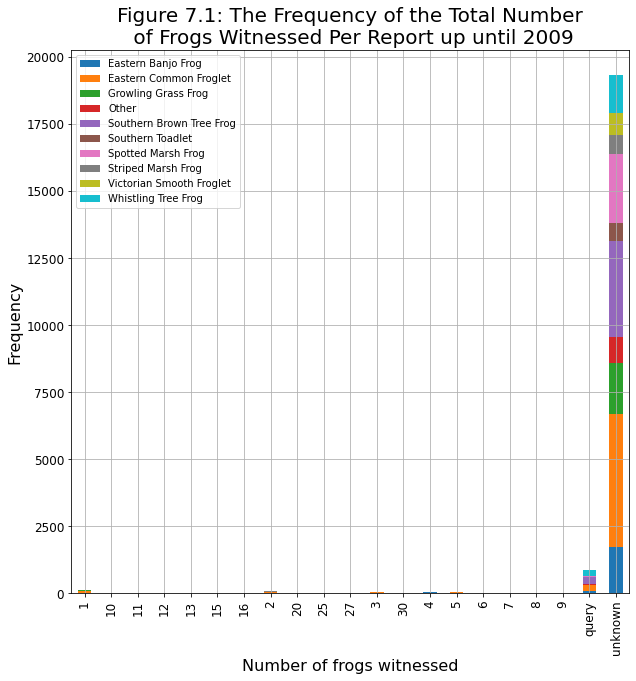

```python
# Grouping and counting data
fig7 = selection.groupby(['Number', "Common_name"])['Number'].count().unstack("Common_name").fillna(0)

# Plotting and styling the grouped data, Number column is currently a string so they aren't numerically ordered. No matter.
fig7.plot(kind='bar', stacked=True, figsize = (10,10), fontsize= 12, grid=True)
plt.legend(loc = "best")
plt.title("Figure 7.1: The Frequency of the Total Number\n of Frogs Witnessed Per Report up until 2009", fontsize = 20)
plt.xlabel("Number of frogs witnessed", fontsize = 16)
plt.ylabel("Frequency", fontsize = 16)
plt.show()
```

```
This subset of data uses only 428 rows
```

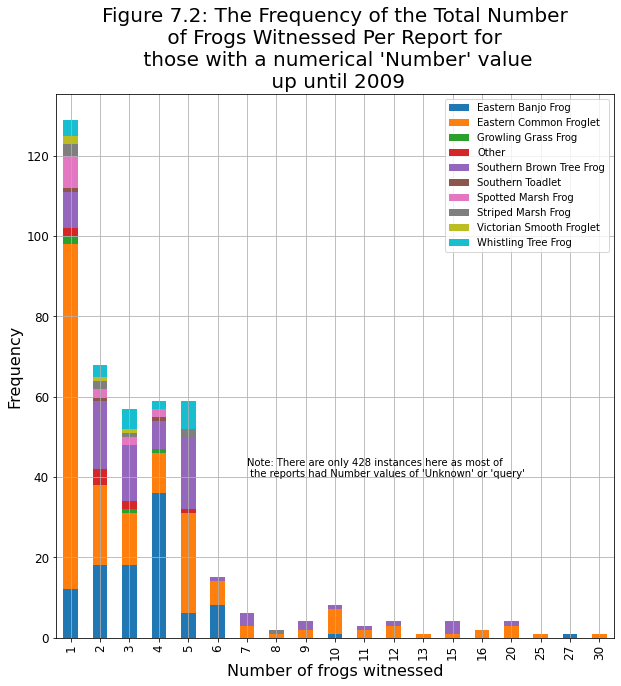

```python
# Lets remove unknown and query values, and turn the string into an integer and see what we see:
selection2 = selection[selection.Number != "unknown"]
selection2 = selection2[selection2.Number != "query"]
selection2['Number'] = selection2['Number'] .astype(int)
print("This subset of data uses only", selection2.Number.count(), "rows")

# Plot and style the data again now that Number column is integers
fig72 = selection2.groupby(['Number', "Common_name"])['Number'].count().unstack("Common_name").fillna(0)
fig72.plot(kind='bar', stacked=True, figsize = (10,10), fontsize= 12, grid=True)
plt.legend(loc = "best")
plt.title("Figure 7.2: The Frequency of the Total Number\n of Frogs Witnessed Per Report for \n those with a numerical 'Number' value\n up until 2009", fontsize = 20)
plt.xlabel("Number of frogs witnessed", fontsize = 16)
plt.ylabel("Frequency", fontsize = 16)
plt.text(6, 40, "Note: There are only 428 instances here as most of\n the reports had Number values of 'Unknown' or 'query'")
plt.show()
```

### Plot 8 - Scatter plot - Where was each species sighted?

(Quantitative variable plotted against quantitative variable with Qualitative labelling)

Below I attempted to map the frog locations.

What this figure shows:

```python
# creating a colour column
cmap = plt.cm.get_cmap('cividis') # Colourblind friendly palette
colour_dict = pd.Series({k:cmap(np.random.rand()) for k in frog_df.Common_name.unique()}, name='color_dict')
df_with_cols = pd.merge(frog_df, colour_dict, how = 'left', left_on = "Common_name", right_index=True)
```

[figure not shown]

```python
# Using location coordinates to map frog location and colour by new colour column
fig8 = frog_df.plot.scatter(x = "Latitude",
                                 y = "Longitude",
                                 ylim = (frog_df.Longitude.min(),df_with_cols.Longitude.max()),
                                 xlim = (frog_df.Latitude.min(),df_with_cols.Latitude.max()),
                                 s=10,
                                 c = df_with_cols.color_dict,
                                 figsize = (15,15),
                                fontsize = 14)
plt.title("Figure 8: The Position of Each Report", fontsize = 20, pad = 40)
plt.xlabel("Latitude (degrees)", fontsize = 14)
plt.ylabel("Longitude (degrees)", fontsize = 14)
plt.legend(df_with_cols.Common_name, title ="Common name")
plt.show()
```

[figure not shown]

```python
fig9, ax = plt.subplots(figsize = (15,15))

colors = {'Eastern Banjo Frog':'blue',
          'Growling Grass Frog': 'green',
          'Spotted Marsh Frog': 'yellow',
       'Eastern Common Froglet':'red',
          'Southern Toadlet':'black',
       'Victorian Smooth Froglet': 'cyan',
          'Southern Brown Tree Frog': 'magenta',
          'Other':'darkgreen',
       'Striped Marsh Frog':"darkblue",
          'Whistling Tree Frog':'grey'}

grouped = frog_df_pie.groupby('Common_name')

for key, group in grouped:
    group.plot(ax=ax, kind='scatter',
               x='Latitude', y='Longitude',
               label=key, color=colors[key],
                s =6, fontsize = 14,
               ylim = (frog_df.Longitude.min(),df_with_cols.Longitude.max()),
               xlim = (frog_df.Latitude.min(),df_with_cols.Latitude.max()))

plt.legend(labels= other,loc = "lower left",fontsize = 14)
plt.xlabel("Latitude (°)", fontsize =16)
plt.ylabel("Longitude (°)", fontsize =16)
plt.title("Figure 9: The Location of Sighting for each Frog Type Reported", fontsize =20, pad= 20)
plt.show()
```

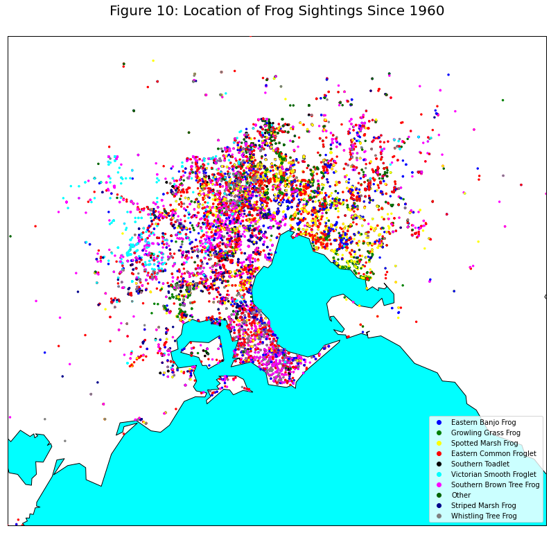

```python
fig10 = plt.gcf()
fig10.set_size_inches(16, 13)

# setup Lambert Conformal basemap.
vicmap = Basemap(projection = 'merc', resolution = 'i',
                 lat_0 = -36.9848, lon_0 = 143.3906,
                 llcrnrlon = frog_df.Longitude.max(), llcrnrlat=frog_df.Latitude.min(),
                 urcrnrlon = frog_df.Longitude.min(), urcrnrlat=frog_df.Latitude.max()) #center on victoria
# draw coastlines.
vicmap.drawcoastlines()
# draw a boundary around the map, fill the background.
# this background will end up being the ocean color, since
# the continents will be drawn on top.
vicmap.drawmapboundary(fill_color='aqua')
# fill continents, set lake color same as ocean color.
vicmap.fillcontinents(color='white',lake_color='lightblue')

x, y = vicmap(frog_df.Longitude.to_list(), frog_df.Latitude.to_list())  # transform coordinates
plt.scatter(x, y, s= 6, marker='o', color = [colors[i] for i in frog_df_pie['Common_name']], zorder = 3)
plt.title("Figure 10: Location of Frog Sightings Since 1960", fontsize = 20, pad = 30)

scatter_markers = []
for key, value in colors.items():
    scatter_markers.append(Line2D([0], [0], color = value, marker = 'o', ls ='none', label = key))

plt.legend(handles = scatter_markers)
plt.show()
```

### Heat map

This figure takes Pearon's correlation coefficients from a correlation matrix and plots them with a colour map to create a visualization of how well two variables are related.

**How it was done**: First I removed unnecessary columns, then I applied the corr() method to the frog_df dataframe setting the method to Pearson to aquire a Pearson's correlation matrix. I then introduce a figure object with matplotlibs figure() function. I then use the matshow() function from the matplotlib library to present the matrix as a plot. Finally, I place the colour bar to indicate correlation strength with the matplotlib labrary's colorbar() function.

**Further commentary**: Had my initial plan been successful there would have been several more columns of variables, but weather data on such a scale as this is extremely hard to come by (*see Extension for details*). I would have compiled the mean number of reports recieved on each month and generated a heat map with weather variables. It would have indicated variables that frogs sightings are most sensitive to, either because the climate is ideal for frogs, or the area has characteristics that influence a persons ability to sight a frog.

```python
frog_df.drop(["Unnamed: 0", "Unnamed: 0.1", "Unnamed: 0.1.1"], axis=1, inplace=True)
correlation_matrix = frog_df.corr(method ='pearson')
print("The correlation matrix for Quantitative variables in the frog_df dataframe:")
correlation_matrix
```

```
The correlation matrix for Quantitative variables in the frog_df dataframe:
```

|  | X | Y | FID | Unique_ID | Latitude | Longitude | Year | Month |
| --- | --- | --- | --- | --- | --- | --- | --- | --- |
| X | 1.000000 | -0.254842 | -0.062751 | -0.067633 | -0.272004 | 0.999743 | -0.102038 | 0.006289 |
| Y | -0.254842 | 1.000000 | -0.104623 | -0.099860 | 0.999839 | -0.233154 | -0.146706 | 0.110564 |
| FID | -0.062751 | -0.104623 | 1.000000 | 0.998004 | -0.103102 | -0.065375 | 0.929180 | 0.211100 |
| Unique_ID | -0.067633 | -0.099860 | 0.998004 | 1.000000 | -0.098251 | -0.070185 | 0.919591 | 0.208012 |
| Latitude | -0.272004 | 0.999839 | -0.103102 | -0.098251 | 1.000000 | -0.250413 | -0.144331 | 0.109819 |
| Longitude | 0.999743 | -0.233154 | -0.065375 | -0.070185 | -0.250413 | 1.000000 | -0.105860 | 0.009095 |
| Year | -0.102038 | -0.146706 | 0.929180 | 0.919591 | -0.144331 | -0.105860 | 1.000000 | 0.184915 |
| Month | 0.006289 | 0.110564 | 0.211100 | 0.208012 | 0.109819 | 0.009095 | 0.184915 | 1.000000 |

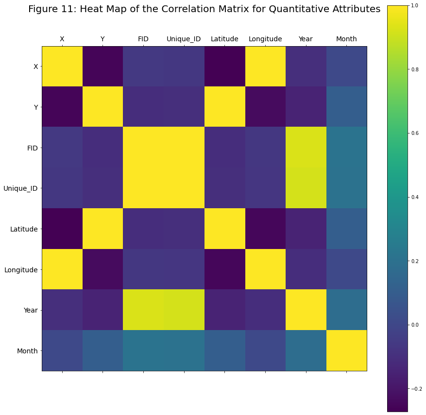

```python
fig11 = plt.figure(figsize = (15,15))
plt.matshow(correlation_matrix, fignum=fig11.number)
plt.colorbar()
ax.tick_params(labelsize=14)
plt.title("Figure 11: Heat Map of the Correlation Matrix for Quantitative Attributes", fontsize = 20, pad =70)
plt.xticks([0,1,2,3,4,5,6,7], ['X', "Y", "FID", "Unique_ID", "Latitude", "Longitude", "Year", "Month"], fontsize=14)
plt.yticks([0,1,2,3,4,5,6,7], ['X', "Y", "FID", "Unique_ID", "Latitude", "Longitude", "Year", "Month"], fontsize=14)
plt.show()
```

#### References:

1. Ari, N & Ustazhanov, M 2014, 'Matplotlib in python', in *2014 11th International Conference on Electronics, Computer and Computation (ICECCO)*, IEEE.
2. Crameri, F, Shephard, GE & Heron, PJ 2020, 'The misuse of colour in science communication', *Nature Communications*, vol. 11, no. 1, 2020-12-01.
3. Harris, CR, Millman, KJ, Van Der Walt, SJ, Gommers, R, Virtanen, P, Cournapeau, D, Wieser, E, Taylor, J, Berg, S, Smith, NJ, Kern, R, Picus, M, Hoyer, S, Van Kerkwijk, MH, Brett, M, Haldane, A, Del Río, JF, Wiebe, M, Peterson, P, Gérard-Marchant, P, Sheppard, K, Reddy, T, Weckesser, W, Abbasi, H, Gohlke, C & Oliphant, TE 2020, 'Array programming with NumPy', *Nature*, vol. 585, no. 7825, 2020-09-17, pp. 357-362.
4. Hunter, JD 2007, 'Matplotlib: A 2D graphics environment', *Computing in science & engineering*, vol. 9, no. 03, pp. 90-95.
5. McKinney, W 2011, 'pandas: a foundational Python library for data analysis and statistics', *Python for high performance and scientific computing*, vol. 14, no. 9, pp. 1-9.
6. Rossum, Gv 1995, 'Python reference manual', *Department of Computer Science* [CS], no. R 9525, CWI, https://ir.cwi.nl/pub/5008.

### Extension:

Lets think of frogs more generally now and combine the date to represent frogs found at each location per month. I'm going to try to create a heat map to show the relationship between these sightings and mean temperature and humidities for that time. I've scoured the internet looking for a dataset that covers even a subset of the area. But none were available and BOM did not have the dataset available free of charge. I have managed to find a weather dataset that forecasted the weather around Australia. So as a proof of concept I will use that:

I have written the code below that would have mapped the nearest weather station to each frog sighting location. With enough weather data, I could have made comments about the ideal weather for each species or for best odds of sighting a frog based on weather conditions.

It appears there is an equation that can find the distance between co-ordinate locations called the 'Haversine' formula. I write a function for it below:

1. Creating the functions needed:

```python
from math import radians, cos, sin, asin, sqrt
# The Haversine formula
def haversine(latitude1, longitude1, latitude2, longitude2):
    # Needs to be in radians
    latitude1, longitude1, latitude2, longitude2 = map(radians, [latitude1, longitude1, latitude2, longitude2])
    # haversine formula
    difflongitude = longitude2 - longitude1
    difflatitude = latitude2 - latitude1
    a = sin(difflatitude/2)**2 + cos(latitude1) * cos(latitude2) * sin(longitude2/2)**2
    c = 2 * asin(sqrt(a))
    # 6371 for the earth's circumfrence
    km = 6371* c
    return km

# Finding the nearest weather location, df will be the weather_df
def find_nearest(latitude, longitude):
    distances = weather_df.apply(
        lambda row: haversine(latitude, longitude, row['LAT'], row['LON']),
        axis=1)
    return weather_df.loc[distances.idxmin(), 'STN_ID']
```

```python
##############    Preparing files
# Identifying the area our data spans across
frog_csv = pd.read_csv("frog_data.csv")
print( "The maximum latitude is: ", frog_csv["Latitude"].max())
print( "The minimum latitude is: ", frog_csv["Latitude"].min())
print( "The maximum longitude is: ", frog_csv["Longitude"].max())
print( "The maximum longitude is: ", frog_csv["Longitude"].min())

mean_humidity_data = pd.read_csv("mean_humidity.csv")
print("With all locations the shape of the dataframe is: ", mean_humidity_data.shape)

# Obtaining the humidity data within the area of our data
relevant_humidity_data = mean_humidity_data.loc[(mean_humidity_data["LAT"] >= -39.073162) & (mean_humidity_data["LAT"] <= -37.01971) &
                                          (mean_humidity_data["LON"] >= 143.55423) & (mean_humidity_data["LON"] <= 146.42387)]
print("With only relevant locations the shaope of the dataframe is: ", relevant_humidity_data.shape)

mean_temp_data = pd.read_csv("temp_data.csv")
print("With all locations the shape of the dataframe is: ", mean_temp_data.shape)

# Obtaining the temperature data within the area of our data
relevant_temp_data =  mean_temp_data.loc[( mean_temp_data["LAT"] >= -39.073162) & ( mean_temp_data["LAT"] <= -37.01971) &
                                          ( mean_temp_data["LON"] >= 143.55423) & ( mean_temp_data["LON"] <= 146.42387)]
print("With only relevant locations the shaope of the dataframe is: ", relevant_temp_data.shape)
```

```
The maximum latitude is:  -37.01971
The minimum latitude is:  -39.073162
The maximum longitude is:  146.42387
The maximum longitude is:  143.55423
With all locations the shape of the dataframe is:  (4160, 27)
With only relevant locations the shaope of the dataframe is:  (208, 27)
With all locations the shape of the dataframe is:  (11648, 27)
With only relevant locations the shaope of the dataframe is:  (208, 27)
```

1. Merging the humidity and temperature datasets:

```python
print(relevant_humidity_data.columns)
print(relevant_temp_data.columns)
```

```
Index(['STATION_NAME', 'STN_ID', 'LAT', 'LON', 'ENSEMBLE', 'RCP', 'MODEL',
       'CLIMATOLOGY', 'Annual', 'DJF', 'MAM', 'JJA', 'SON', 'NDJFMA', 'MJJASO',
       'January', 'February', 'March', 'April', 'May', 'June', 'July',
       'August', 'September', 'October', 'November', 'December'],
      dtype='object')
Index(['STATION_NAME', 'STN_ID', 'LAT', 'LON', 'ENSEMBLE', 'RCP', 'MODEL',
       'CLIMATOLOGY', 'Annual', 'DJF', 'MAM', 'JJA', 'SON', 'NDJFMA', 'MJJASO',
       'January', 'February', 'March', 'April', 'May', 'June', 'July',
       'August', 'September', 'October', 'November', 'December'],
      dtype='object')
```

```python
weather_df = pd.merge(relevant_humidity_data, relevant_temp_data, on=["STN_ID", "LAT", "LON", "STATION_NAME",
                                                                      "ENSEMBLE", "RCP", "MODEL",])
weather_df["Annual_mean_Humidity"] = weather_df.Annual_x
weather_df["Annual_mean_temp"] = weather_df.Annual_y
weather_df = weather_df.drop(["Annual_x", "Annual_y"], axis=1)
weather_df = pd.DataFrame(weather_df)
weather_df
```

|  | STATION_NAME | STN_ID | LAT | LON | ENSEMBLE | RCP | MODEL | CLIMATOLOGY_x | DJF_x | MAM_x | ... | May_y | June_y | July_y | August_y | September_y | October_y | November_y | December_y | Annual_mean_Humidity | Annual_mean_temp |
| --- | --- | --- | --- | --- | --- | --- | --- | --- | --- | --- | --- | --- | --- | --- | --- | --- | --- | --- | --- | --- | --- |
| 0 | LAVERTON-RAAF | 87031 | -37.86 | 144.76 | r1i1p1 | rcp26 | CESM1-CAM5 | 2020-2039 | 66.36 | 75.78 | ... | 18.36 | 15.61 | 15.25 | 16.03 | 17.64 | 20.28 | 22.23 | 24.61 | 72.72 | 20.82 |
| 1 | LAVERTON-RAAF | 87031 | -37.86 | 144.76 | r1i1p1 | rcp26 | CESM1-CAM5 | 2020-2039 | 66.36 | 75.78 | ... | 18.58 | 15.86 | 15.52 | 16.32 | 18.18 | 20.41 | 22.88 | 24.54 | 72.72 | 21.13 |
| 2 | LAVERTON-RAAF | 87031 | -37.86 | 144.76 | r1i1p1 | rcp26 | CESM1-CAM5 | 2020-2039 | 66.36 | 75.78 | ... | 19.16 | 16.33 | 15.63 | 16.59 | 18.53 | 20.96 | 23.24 | 25.42 | 72.72 | 21.61 |
| 3 | LAVERTON-RAAF | 87031 | -37.86 | 144.76 | r1i1p1 | rcp26 | CESM1-CAM5 | 2020-2039 | 66.36 | 75.78 | ... | 18.89 | 16.25 | 15.79 | 16.98 | 18.33 | 21.18 | 23.50 | 25.40 | 72.72 | 21.63 |
| 4 | LAVERTON-RAAF | 87031 | -37.86 | 144.76 | r1i1p1 | rcp26 | CESM1-CAM5 | 2040-2059 | 66.18 | 76.05 | ... | 18.36 | 15.61 | 15.25 | 16.03 | 17.64 | 20.28 | 22.23 | 24.61 | 72.68 | 20.82 |
| ... | ... | ... | ... | ... | ... | ... | ... | ... | ... | ... | ... | ... | ... | ... | ... | ... | ... | ... | ... | ... | ... |
| 411 | LAVERTON-RAAF | 87031 | -37.86 | 144.76 | r1i1p1 | rcp85 | NorESM1-M | 2060-2079 | 67.87 | 75.06 | ... | 19.67 | 17.34 | 16.39 | 17.43 | 19.82 | 22.28 | 24.33 | 26.42 | 72.86 | 22.46 |
| 412 | LAVERTON-RAAF | 87031 | -37.86 | 144.76 | r1i1p1 | rcp85 | NorESM1-M | 2080-2099 | 68.61 | 75.31 | ... | 18.09 | 15.60 | 14.57 | 15.69 | 17.88 | 20.46 | 22.28 | 24.48 | 72.74 | 20.70 |
| 413 | LAVERTON-RAAF | 87031 | -37.86 | 144.76 | r1i1p1 | rcp85 | NorESM1-M | 2080-2099 | 68.61 | 75.31 | ... | 18.61 | 15.86 | 14.97 | 16.39 | 18.38 | 21.25 | 23.19 | 24.84 | 72.74 | 21.25 |
| 414 | LAVERTON-RAAF | 87031 | -37.86 | 144.76 | r1i1p1 | rcp85 | NorESM1-M | 2080-2099 | 68.61 | 75.31 | ... | 19.07 | 16.85 | 15.84 | 16.90 | 19.16 | 21.76 | 23.47 | 25.64 | 72.74 | 21.84 |
| 415 | LAVERTON-RAAF | 87031 | -37.86 | 144.76 | r1i1p1 | rcp85 | NorESM1-M | 2080-2099 | 68.61 | 75.31 | ... | 19.67 | 17.34 | 16.39 | 17.43 | 19.82 | 22.28 | 24.33 | 26.42 | 72.74 | 22.46 |

416 rows × 47 columns

1. Unfortunately the Above dataset has only a single weather station prediction for different decades and models, completely useless for what I wanted to show

The next step would have been to ensure the coordinates are as floats and then creating a new column in the frog_df:

```python
frog_df.Longitude = frog_df.Longitude.astype(float)
frog_df.Latitude = frog_df.Latitude.astype(float)
weather_df.LAT = weather_df.LAT.astype(float)
weather_df.LON = weather_df.LON.astype(float)

#frog_df['WeatherID'] = frog_df.apply(lambda row: find_nearest(row['Latitude'], row['Longitude']), axis=1)
```

1. The final thing to do was to merge the dataset together and use it for analysis:

```python
# Merge the two data sets on Date index and new WeatherID column
# frog_df = pd.merge(frog_df, weather_df,left_index=True, right_on='WeatherID')


# May need to Melt data, if so here is the code:
# frog_df = pd.melt(frog_df, id_vars=["Unnamed: 0", "Unnamed: 0.1", "Unnamed: 0.1.1", "X", "Y",
#                                    "FID", "Unique_ID", "Date", "Time_Start", "Latitude", "Longitude",
#                                    "Type_of_observation", "Scientific_name", "Common_name", "Number", "Suburb"],
#                             value_vars=[Columns to melt],
#                             var_name= "melted columns column name",
#                             value_name="New column name for melted values",
#                             ignore_index=True)
#relevant_temp_data
```

Although I couldn't find the data to make this work, I was excited to see that it was possible and that I could do it with my limited knowledge. I didn't want to remove it entirely as this took me a good four days looking for datastes and writing the code. So I decided to leave it in as something of an Appendix.